# Bank Churn Prediction

### Model Improvement: Neural Network model with Adam Optimizer

```python
# Clearing backend to help avoid clutter from old models and layers, and clear up memory.
backend.clear_session()
# Fixing the seed for random number generators so that we can ensure we receive the same output everytime.
np.random.seed(13)
import random
random.seed(13)
tf.random.set_seed(13)
```

```python
# Creating a sequential model.
model1 = Sequential()
# Adding the hidden and output layers.
model1.add(Dense(64,activation='relu',input_dim = X_train.shape[1]))
model1.add(Dense(32,activation='relu'))
model1.add(Dense(1, activation = 'sigmoid'))
```

```python
# Compiling with Adam optimizer and binary cross entropy loss function.
optimizer1 = tf.keras.optimizers.Adam(0.001)
model1.compile(loss='binary_crossentropy',optimizer=optimizer1,metrics=[keras.metrics.Recall()])
```

```python
# Checking the summary of the model.
model1.summary()
```

```
Model: "sequential"
_________________________________________________________________
 Layer (type)                Output Shape              Param #
=================================================================
 dense (Dense)               (None, 64)                768

 dense_1 (Dense)             (None, 32)                2080

 dense_2 (Dense)             (None, 1)                 33

=================================================================
Total params: 2,881
Trainable params: 2,881
Non-trainable params: 0
_________________________________________________________________
```

```python
# Fitting the model to training data and storing the results.
history1 = model1.fit(X_train,
                      y_train,
                      batch_size=64,
                      epochs=50,
                      verbose=1,
                      validation_data=(X_val, y_val))
print("*" * 130)
print("Model has been fit to training data.")
```

```
Model has been fit to training data.
```

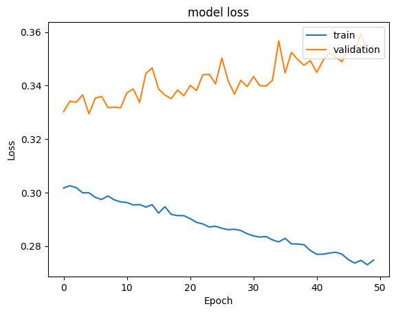

```python
# Plotting Train Loss vs Validation Loss.
plt.plot(history1.history['loss'])
plt.plot(history1.history['val_loss'])
plt.title('model loss')
plt.ylabel('Loss')
plt.xlabel('Epoch')
plt.legend(['train', 'validation'], loc='upper right')
plt.show()
```

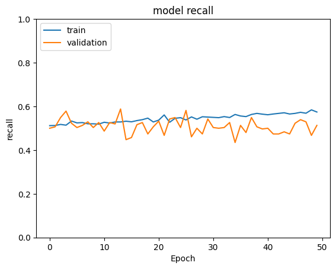

```python
# Plotting Train recall vs Validation recall.
plt.plot(history1.history['recall'])
plt.plot(history1.history['val_recall'])
plt.title('model recall')
plt.ylabel('recall')
plt.xlabel('Epoch')
plt.legend(['train', 'validation'], loc='upper left')
plt.ylim(0, 1)
plt.show()
```

```
Best Threshold=0.221491, G-Mean=0.844
```

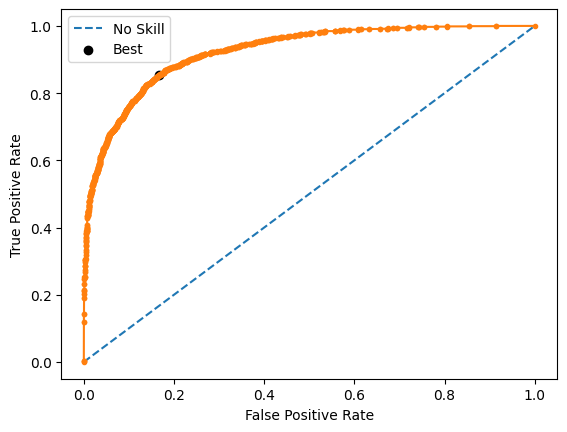

```python
# Calculate Best Threshold.
yhat1 = model1.predict(X_train)
# Keeping probabilities for the positive outcomes only.
yhat1 = yhat1[:, 0]
# Calculating roc curves.
fpr, tpr, thresholds1 = roc_curve(y_train, yhat1)
# Calculating the g-mean for each threshold.
gmeans1 = np.sqrt(tpr * (1-fpr))
# Locating the index of the largest g-mean.
ix = np.argmax(gmeans1)
print('Best Threshold=%f, G-Mean=%.3f' % (thresholds1[ix], gmeans1[ix]))
# Plotting the roc curve for the model.
plt.plot([0,1], [0,1], linestyle='--', label='No Skill')
plt.plot(fpr, tpr, marker='.')
plt.scatter(fpr[ix], tpr[ix], marker='o', color='black', label='Best')
# Axis labels.
plt.xlabel('False Positive Rate')
plt.ylabel('True Positive Rate')
plt.legend()
# Showing the plot.
plt.show()
```

```python
# Predicting the results using best as a threshold.
y_train_pred1 = model1.predict(X_train)
y_train_pred1 = (y_train_pred1 > thresholds1[ix])
y_train_pred1
```

```
array([[False],
       [False],
       [False],
       ...,
       [False],
       [False],
       [ True]])
```

```python
# Predicting the results using best as a threshold.
y_val_pred1 = model1.predict(X_val)
y_val_pred1 = (y_val_pred1 > thresholds1[ix])
y_val_pred1
```

```
array([[False],
       [False],
       [ True],
       ...,
       [False],
       [False],
       [ True]])
```

```python
model_name = "NN with Adam Optimizer"

train_metric_df.loc[model_name] = recall_score(y_train,y_train_pred1)
valid_metric_df.loc[model_name] = recall_score(y_val,y_val_pred1)
```

```python
#classification report
cr=classification_report(y_train,y_train_pred1)
print(cr)
```

```
              precision    recall  f1-score   support

         0.0       0.96      0.83      0.89      5574
         1.0       0.57      0.85      0.68      1426

    accuracy                           0.84      7000
   macro avg       0.76      0.84      0.79      7000
weighted avg       0.88      0.84      0.85      7000
```

```python
#classification report
cr=classification_report(y_val,y_val_pred1)
print(cr)
```

```
              precision    recall  f1-score   support

         0.0       0.93      0.81      0.86      1194
         1.0       0.50      0.75      0.60       306

    accuracy                           0.80      1500
   macro avg       0.71      0.78      0.73      1500
weighted avg       0.84      0.80      0.81      1500
```

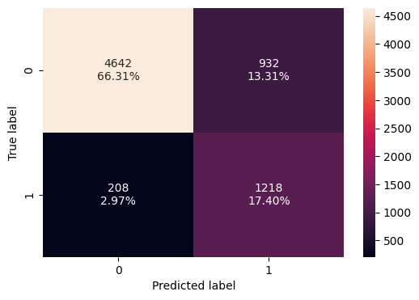

```python
#Calculating the confusion matrix
make_confusion_matrix(y_train, y_train_pred1)
```

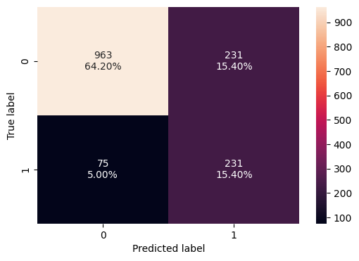

```python
#Calculating the confusion matrix
make_confusion_matrix(y_val, y_val_pred1)
```

**Observations :**

**Neural Network model with Adam Optimizer**

**Recall Analysis for Training Data:**

1.Class 0 (Non-Churners): The recall is 0.83, indicating the model correctly identifies 83% of non-churning customers. Given that this class is the majority, the model performs well but could still improve.

2.Class 1 (Churners): The recall is 0.85, showing that the model captures 85% of actual churners. This is a strong recall rate for churners, suggesting the model is good at identifying those likely to leave.

3.Macro Average Recall: 0.84, indicating a balanced ability to detect both classes correctly.

**Recall Analysis for Validation Data:**

1.Class 0 (Non-Churners): The recall is 0.81, slightly lower than in training, which suggests some degradation in model performance on unseen data for this class.

2.Class 1 (Churners): The recall is 0.75, also lower than in training. This drop indicates the model misses 25% of the churners in the validation set, which could be critical for business decisions.

3.Macro Average Recall: 0.78, showing a drop from the training set. This might indicate some overfitting to the training data or that the validation data presents slightly different characteristics.

**Overall Performance Evaluation:**

Training Set: High recall for churners (0.85) indicates the model learns well from the training data to detect churn. This is critical for identifying most of the churners and taking preventive actions. Validation Set: While recall for churners (0.75) is still reasonable, the drop from the training set suggests the model's generalization to new data could be improved.

**Improve Recall for Churners:**

Further fine-tuning of the model to enhance recall for Class 1 (churners) is essential. Consider techniques like ensemble methods, cost-sensitive learning, or adjusting class weights.

1.Threshold Adjustment: Experimenting with different decision thresholds could optimize the recall-precision trade-off for churners. Enhance Model Generalization:

2.Reducing the gap between training and validation performance is crucial. Techniques such as cross-validation, regularization, and dropout adjustments can help.

3.Feature Engineering: Investigate additional features or interactions that may help the model better capture the factors leading to churn. Balance Precision and Recall:

4.While improving recall is important for churn prediction, maintaining a balance with precision ensures the model doesn't generate too many false positives. This balance is crucial for actionable insights and effective business strategies.

5.Practical Business Actions: Using the model's predictions, focus retention efforts on customers flagged as potential churners, and continuously refine the model with new data to adapt to changing customer behaviors.

### Model Improvement: Neural Network with Adam Optimizer and Dropout

```python
# Clearing backend to help avoid clutter from old models and layers, and clear up memory.
backend.clear_session()
# Fixing the seed for random number generators so that we can ensure we receive the same output everytime.
np.random.seed(13)
import random
random.seed(13)
tf.random.set_seed(13)
```

```python
# Creating a sequential model.
model2 = Sequential()
# Adding the hidden and output layers with drop out.
model2.add(Dense(128,activation='relu',input_dim = X_train.shape[1]))
model2.add(Dropout(0.2))
model2.add(Dense(64,activation='relu'))
model2.add(Dropout(0.2))
model2.add(Dense(32,activation='relu'))
model2.add(Dense(1, activation = 'sigmoid'))
```

```python
# Checking the summary of the model.
model2.summary()
```

```
Model: "sequential"
_________________________________________________________________
 Layer (type)                Output Shape              Param #
=================================================================
 dense (Dense)               (None, 128)               1536

 dropout (Dropout)           (None, 128)               0

 dense_1 (Dense)             (None, 64)                8256

 dropout_1 (Dropout)         (None, 64)                0

 dense_2 (Dense)             (None, 32)                2080

 dense_3 (Dense)             (None, 1)                 33

=================================================================
Total params: 11,905
Trainable params: 11,905
Non-trainable params: 0
_________________________________________________________________
```

```python
# Compiling with Adam optimizer and binary cross entropy loss function.
optimizer2 = tf.keras.optimizers.Adam(0.001)
model2.compile(loss='binary_crossentropy',optimizer=optimizer2,metrics=[keras.metrics.Recall()])
```

```python
# Fitting the model to training data and storing the results.
history2 = model2.fit(X_train,
                      y_train,
                      batch_size=64,
                      epochs=50,
                      verbose=1,
                      validation_data=(X_val, y_val))
print("*" * 130)
print("Model has been fit to training data.")
```

```
Model has been fit to training data.
```

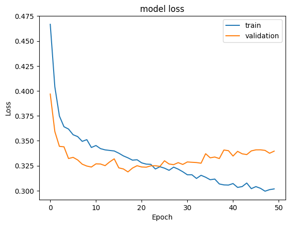

```python
#Plotting Train Loss vs Validation Loss
plt.plot(history2.history['loss'])
plt.plot(history2.history['val_loss'])
plt.title('model loss')
plt.ylabel('Loss')
plt.xlabel('Epoch')
plt.legend(['train', 'validation'], loc='upper right')
plt.show()
```

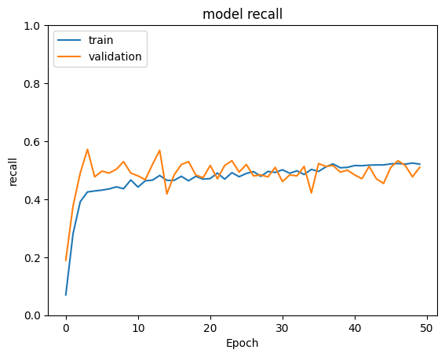

```python
# Plotting Train recall vs Validation recall.
plt.plot(history2.history['recall'])
plt.plot(history2.history['val_recall'])
plt.title('model recall')
plt.ylabel('recall')
plt.xlabel('Epoch')
plt.legend(['train', 'validation'], loc='upper left')
plt.ylim(0, 1)
plt.show()
```

```
Best Threshold=0.199934, G-Mean=0.837
```

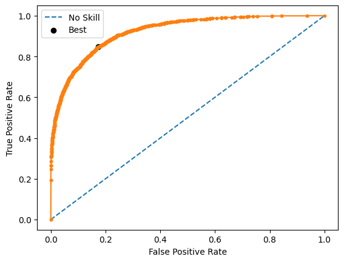

```python
# Predicting probabilities.
yhat2 = model2.predict(X_train)
# Keeping probabilities for the positive outcomes only.
yhat2 = yhat2[:, 0]
# Calculating roc curves.
fpr, tpr, thresholds2 = roc_curve(y_train, yhat2)
# Calculating the g-mean for each threshold.
gmeans2 = np.sqrt(tpr * (1-fpr))
# Locating the index of the largest g-mean.
ix = np.argmax(gmeans2)
print('Best Threshold=%f, G-Mean=%.3f' % (thresholds2[ix], gmeans2[ix]))
# Plotting the roc curve for the model.
plt.plot([0,1], [0,1], linestyle='--', label='No Skill')
plt.plot(fpr, tpr, marker='.')
plt.scatter(fpr[ix], tpr[ix], marker='o', color='black', label='Best')
# Axis labels.
plt.xlabel('False Positive Rate')
plt.ylabel('True Positive Rate')
plt.legend()
# Showing the plot.
plt.show()
```

```python
# Predicting the results using best as a threshold.
y_train_pred2 = model1.predict(X_train)
y_train_pred2 = (y_train_pred2 > thresholds2[ix])
y_train_pred2
```

```
array([[False],
       [ True],
       [False],
       ...,
       [False],
       [False],
       [ True]])
```

```python
# Predicting the results using best as a threshold.
y_val_pred2 = model2.predict(X_val)
y_val_pred2 = (y_val_pred2 > thresholds2[ix])
y_val_pred2
```

```
array([[False],
       [False],
       [ True],
       ...,
       [False],
       [False],
       [ True]])
```

```python
model_name = "NN with Adam Optimizer and Dropout"

train_metric_df.loc[model_name] = recall_score(y_train,y_train_pred2)
valid_metric_df.loc[model_name] = recall_score(y_val,y_val_pred2)
```

```python
#lassification report
cr=classification_report(y_train,y_train_pred2)
print(cr)
```

```
              precision    recall  f1-score   support

         0.0       0.96      0.81      0.88      5574
         1.0       0.54      0.88      0.67      1426

    accuracy                           0.82      7000
   macro avg       0.75      0.84      0.77      7000
weighted avg       0.88      0.82      0.83      7000
```

```python
#classification report
cr=classification_report(y_val,y_val_pred2)
print(cr)
```

```
              precision    recall  f1-score   support

         0.0       0.93      0.79      0.86      1194
         1.0       0.49      0.76      0.59       306

    accuracy                           0.79      1500
   macro avg       0.71      0.78      0.72      1500
weighted avg       0.84      0.79      0.80      1500
```

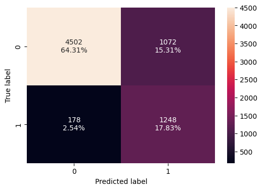

```python
#Calculating the confusion matrix
make_confusion_matrix(y_train, y_train_pred2)
```

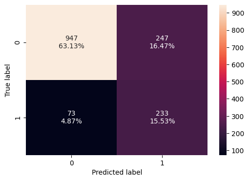

```python
#Calculating the confusion matrix
make_confusion_matrix(y_val, y_val_pred2)
```

**Observation :**

**Neural Network with Adam Optimizer and Dropout**

**Recall Analysis for Training Data:**

Class 0 (Non-Churners): The recall is 0.81, indicating the model correctly identifies 81% of non-churning customers. Given that this class is the majority, the model performs reasonably well.

Class 1 (Churners): The recall is 0.88, showing that the model captures 88% of actual churners. This is a high recall rate for churners, suggesting the model is very effective at identifying those likely to leave.

Macro Average Recall: 0.84, reflecting a balanced ability to detect both classes correctly, with a slight emphasis on the minority class (churners) due to its critical business impact.

**Recall Analysis for Validation Data:**

Class 0 (Non-Churners): The recall is 0.79, slightly lower than in training, indicating some degradation in model performance on unseen data for this class.

Class 1 (Churners): The recall is 0.76, also lower than in training. This drop suggests the model misses 24% of the churners in the validation set, which could be critical for business decisions.

Macro Average Recall: 0.78, showing a drop from the training set. This might indicate some overfitting to the training data or that the validation data presents slightly different characteristics.

**Overall Performance Evaluation:**

Training Set: The high recall for churners (0.88) indicates the model learns well from the training data to detect churn. This is critical for identifying most of the churners and taking preventive actions. Validation Set: The recall for churners (0.76) remains relatively strong, but the drop from the training set indicates potential overfitting or data distribution differences. Improving generalization is key.

**Conclusions and Recommendations:** Improve Recall for Churners by fine tuning model with ensemble methods, adjusting class weights, applying cost sensitive learning, apply various decision thresholds to optimize recall-precision trade off for churners.

1. Enhance Model Generalization:Reducing the gap between training and validation performance with Techniques such as cross-validation, regularization, and dropout adjustments can help.
2. Feature Engineering: Investigate additional features or interactions that may help the model better capture the factors leading to churn. Analyzing feature importance and potential non-linear relationships could be beneficial.

**Balance Precision and Recall:**

While improving recall is crucial for churn prediction, maintaining a balance with precision ensures the model doesn't generate too many false positives. This balance is vital for actionable insights and effective business strategies.

**Practical Business Actions:**

Using the model's predictions, focus retention efforts on customers flagged as potential churners, and continuously refine the model with new data to adapt to changing customer behaviors.

- This model performed slightly simillar with previous model i.e 0.76 recall on validation set with accuracy of 79% , Results in approx 5 % of customers exiting without the bank attempting to intervene.

```python
# Clearing backend to help avoid clutter from old models and layers, and clear up memory.
backend.clear_session()
# Fixing the seed for random number generators so that we can ensure we receive the same output everytime.
np.random.seed(13)
import random
random.seed(13)
tf.random.set_seed(13)
```

```python
# Defining function to create and compile ANN.
def create_model(dropout_rate=0.1,lr=0.001,layer_1=64,layer_2=32,batch_size=40):
    np.random.seed(1337)
    #Initializing the neural network
    model3 = Sequential()
    # This adds the input layer (by specifying input dimension).
    model3.add(Dense(layer_1,activation='relu',input_dim = X_train.shape[1]))
    # Adding dropout.
    model3.add(Dropout(0.5))
    # Adding the hidden layer.
    model3.add(Dense(layer_2,activation='relu'))
    # Adding the output layer.
    model3.add(Dense(1, activation='sigmoid'))
    # Adding Adam initializer.
    optimizer = tf.keras.optimizers.Adam(learning_rate=lr)
    # Compiling with Adam optimizer and binary cross entropy loss function.
    model3.compile(optimizer = optimizer,loss = 'binary_crossentropy', metrics = [keras.metrics.Recall()])
    return model3
```

```python
# Creating estimator using KerasClassifier with inital lr of 0.001 and build_fn create_model.
keras_estimator = KerasClassifier(lr= 0.001, build_fn=create_model, verbose=1)
```

```python
# Defining the grid search parameters.
param_grid = {
    'batch_size':[40, 64, 128],
    "lr":[0.01,0.001,0.1]}
# Using 3 folds for validation.
kfold_splits = 3
# Using GridSearchCV to find best parameters for ANN.
grid = GridSearchCV(estimator=keras_estimator,
                    verbose=1,
                    cv=kfold_splits,
                    param_grid=param_grid,
                    n_jobs=-1)
```

### Model Improvement: Neural Network with Balanced Data (by applying SMOTE) and SGD Optimizer

```python
# Applying SMOTE on training data to oversample data.
sm = SMOTE(sampling_strategy='not majority')
X_train_sm , y_train_sm = sm.fit_resample(X_train,y_train)
print('Before resampling, the shape of X_train: {}'.format(X_train.shape))
print('Before resampling, the shape of y_train: {} \n'.format(y_train.shape))
print('After resampling, the shape of X_train: {}'.format(X_train_sm.shape))
print('After resampling, the shape of y_train: {} \n'.format(y_train_sm.shape))
```

```
Before resampling, the shape of X_train: (7000, 11)
Before resampling, the shape of y_train: (7000, 1)

After resampling, the shape of X_train: (11148, 11)
After resampling, the shape of y_train: (11148,)
```

```python
# Checking value counts of y_train before oversampling.
unique_values, counts = np.unique(y_train, return_counts=True)
value_counts = dict(zip(unique_values, counts))
value_counts
```

```
{0.0: 5574, 1.0: 1426}
```

```python
# Checking value counts of y_train_sm after oversampling.
unique_values, counts = np.unique(y_train_sm, return_counts=True)
value_counts = dict(zip(unique_values, counts))
value_counts
```

```
{0.0: 5574, 1.0: 5574}
```

```python
# Clearing backend to help avoid clutter from old models and layers, and clear up memory.
backend.clear_session()
# Fixing the seed for random number generators so that we can ensure we receive the same output everytime.
np.random.seed(13)
import random
random.seed(13)
tf.random.set_seed(13)
```

```python
# Creating a sequential model.
model4 = Sequential()
# Adding the input layer with 32 neurons and relu as the activation function.
model4.add(Dense(32,activation='relu',input_dim = X_train_sm.shape[1]))
# Adding the dropout.
model4.add(Dropout(0.2))
# Adding hidden layer with 16 neurons.
model4.add(Dense(16,activation='relu'))
# Adding the dropout.
model4.add(Dropout(0.1))
# Adding hidden layer with 8 neurons.
model4.add(Dense(8, activation='relu'))
# Adding the output layer.
model4.add(Dense(1, activation = 'relu'))
```

```python
# Printing model summary.
model4.summary()
```

```
Model: "sequential"
_________________________________________________________________
 Layer (type)                Output Shape              Param #
=================================================================
 dense (Dense)               (None, 32)                384

 dropout (Dropout)           (None, 32)                0

 dense_1 (Dense)             (None, 16)                528

 dropout_1 (Dropout)         (None, 16)                0

 dense_2 (Dense)             (None, 8)                 136

 dense_3 (Dense)             (None, 1)                 9

=================================================================
Total params: 1,057
Trainable params: 1,057
Non-trainable params: 0
_________________________________________________________________
```

```python
# Defining EarlyStopping as the callback for this model.
es_cb = keras.callbacks.EarlyStopping(monitor='val_loss', min_delta=0.001, patience=5)

# Initializing Adam optimizer.
optimizer4 = tf.keras.optimizers.SGD(0.001)

# Compiling the model with binary cross entropy as loss and accuracy as metrics.
model4.compile(optimizer=optimizer4,loss = 'binary_crossentropy', metrics = [keras.metrics.Recall()])

# Fitting the model to training data and storing the results.
history4 = model4.fit(X_train_sm,
                      y_train_sm,
                      batch_size=64,
                      epochs=50,
                      verbose=1,
                      validation_data = (X_val,y_val),
                      callbacks=[es_cb])
```

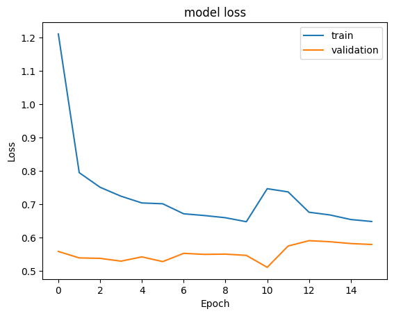

```python
# Plotting Train Loss vs Validation Loss.
plt.plot(history4.history['loss'])
plt.plot(history4.history['val_loss'])
plt.title('model loss')
plt.ylabel('Loss')
plt.xlabel('Epoch')
plt.legend(['train', 'validation'], loc='upper right')
plt.show()
```

[figure not shown]

```python
# Plotting Train recall vs Validation recall.
plt.plot(history4.history['recall'])
plt.plot(history4.history['val_recall'])
plt.title('model recall')
plt.ylabel('recall')
plt.xlabel('Epoch')
plt.legend(['train', 'validation'], loc='upper left')
plt.ylim(0, 1)
plt.show()
```

```
Best Threshold=0.463798, G-Mean=0.695
```

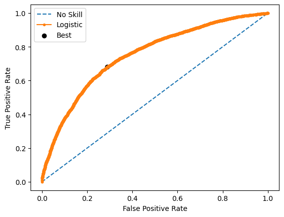

```python
# Predicting probabilities.
yhat4 = model4.predict(X_train_sm)
# Keeping probabilities for the positive outcome only.
yhat4 = yhat4[:, 0]
# Calculating roc curves.
fpr, tpr, thresholds4 = roc_curve(y_train_sm, yhat4)
# Calculating the g-mean for each threshold.
gmeans4 = np.sqrt(tpr * (1-fpr))
# Locating the index of the largest g-mean.
ix = np.argmax(gmeans4)
print('Best Threshold=%f, G-Mean=%.3f' % (thresholds4[ix], gmeans4[ix]))
# Plotting the roc curve for the model.
plt.plot([0,1], [0,1], linestyle='--', label='No Skill')
plt.plot(fpr, tpr, marker='.', label='Logistic')
plt.scatter(fpr[ix], tpr[ix], marker='o', color='black', label='Best')
# Axis labels.
plt.xlabel('False Positive Rate')
plt.ylabel('True Positive Rate')
plt.legend()
# Showing the plot.
plt.show()
```

```python
# Predicting the results using best as a threshold.
y_train_pred4 = model4.predict(X_train_sm)
y_train_pred4 = (y_train_pred4 > thresholds4[ix])
y_train_pred4
```

```
array([[False],
       [ True],
       [False],
       ...,
       [ True],
       [ True],
       [ True]])
```

```python
# Predicting the results using best as a threshold.
y_val_pred4 = model4.predict(X_val)
y_val_pred4 = (y_val_pred4 > thresholds4[ix])
y_val_pred4
```

```
array([[False],
       [False],
       [ True],
       ...,
       [False],
       [False],
       [ True]])
```

```python
model_name = "NN with Balanced Data (by applying SMOTE) and SGD Optimizer"

train_metric_df.loc[model_name] = recall_score(y_train_sm,y_train_pred4)
valid_metric_df.loc[model_name] = recall_score(y_val,y_val_pred4)
```

```python
#classification report
cr=classification_report(y_train_sm,y_train_pred4)
print(cr)
```

```
              precision    recall  f1-score   support

         0.0       0.69      0.71      0.70      5574
         1.0       0.70      0.68      0.69      5574

    accuracy                           0.70     11148
   macro avg       0.70      0.70      0.70     11148
weighted avg       0.70      0.70      0.70     11148
```

```python
#classification report
cr=classification_report(y_val,y_val_pred4)
print(cr)
```

```
              precision    recall  f1-score   support

         0.0       0.91      0.73      0.81      1194
         1.0       0.40      0.71      0.51       306

    accuracy                           0.73      1500
   macro avg       0.65      0.72      0.66      1500
weighted avg       0.80      0.73      0.75      1500
```

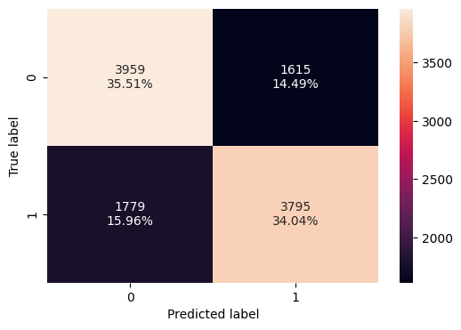

```python
#Calculating the confusion matrix
make_confusion_matrix(y_train_sm, y_train_pred4)
```

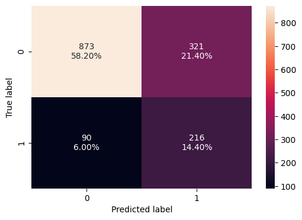

```python
#Calculating the confusion matrix
make_confusion_matrix(y_val, y_val_pred4)
```

**Observations :**

**Neural Network with Balanced Data (by applying SMOTE) and SGD Optimizer**

**Recall Comparison:**

**Overall Accuracy and Averages:**

Training Data: Accuracy of 0.70 indicates that the model correctly predicts the class of 70% of the instances. The macro and weighted averages show consistency across metrics. Validation Data: Accuracy of 0.73 is higher than in training, suggesting some improvement in generalizing to unseen data. However, the macro average reveals a significant disparity in the precision of the two classes.

**Model Generalization:**

The higher recall for Class 1 (churners) in the validation set indicates that the model generalizes well for predicting churners on unseen data. However, the drop in precision for Class 1 suggests a need for better balancing of precision and recall to reduce false positives.

**Conclusions and Recommendations:** Fine-Tuning and Hyperparameter Optimization, Handle Class Imbalance More Effectively with SMOTE,class weighting could help the model better learn from the minority class.

- Prioritize improving the recall for churners while maintaining reasonable precision to minimize the risk of losing actual churners. This will ensure the model is useful in real-world applications for customer retention strategies.
- 71% recall on Validation set is slightly reduced performance than previous model( also reduced accuracy 73%), Resulting in approx 6 % of customers leaving without bank's intervening to retain.

### Model Improvement: Neural Network with Balanced Data (by applying SMOTE) and Adam Optimizer

```python
# Applying SMOTE on training data to oversample data.
sm = SMOTE(sampling_strategy='not majority')
X_train_sm , y_train_sm = sm.fit_resample(X_train,y_train)
print('After resampling, the shape of X_train: {}'.format(X_train.shape))
print('After resampling, the shape of y_train: {} \n'.format(y_train.shape))
```

```
After resampling, the shape of X_train: (7000, 11)
After resampling, the shape of y_train: (7000, 1)
```

```python
# Checking value counts of y_train before oversampling.
unique_values, counts = np.unique(y_train, return_counts=True)
value_counts = dict(zip(unique_values, counts))
value_counts
```

```
{0.0: 5574, 1.0: 1426}
```

```python
# Checking value counts of y_train_sm after oversampling.
unique_values, counts = np.unique(y_train_sm, return_counts=True)
value_counts = dict(zip(unique_values, counts))
value_counts
```

```
{0.0: 5574, 1.0: 5574}
```

```python
# Clearing backend to help avoid clutter from old models and layers, and clear up memory.
backend.clear_session()
# Fixing the seed for random number generators so that we can ensure we receive the same output everytime.
np.random.seed(13)
import random
random.seed(13)
tf.random.set_seed(13)
```

```python
# Creating a sequential model.
model5 = Sequential()
# Adding the input layer with 32 neurons and relu as the activation function.
model5.add(Dense(32,activation='relu',input_dim = X_train_sm.shape[1]))
# Adding hidden layer with 16 neurons.
model5.add(Dense(16,activation='relu'))
# Adding hidden layer with 8 neurons.
model5.add(Dense(8, activation='relu'))
# Adding the output layer.
model5.add(Dense(1, activation = 'relu'))
```

```python
# Printing model summary.
model5.summary()
```

```
Model: "sequential"
_________________________________________________________________
 Layer (type)                Output Shape              Param #
=================================================================
 dense (Dense)               (None, 32)                384

 dense_1 (Dense)             (None, 16)                528

 dense_2 (Dense)             (None, 8)                 136

 dense_3 (Dense)             (None, 1)                 9

=================================================================
Total params: 1,057
Trainable params: 1,057
Non-trainable params: 0
_________________________________________________________________
```

```python
# Defining EarlyStopping as the callback for this model.
es_cb = keras.callbacks.EarlyStopping(monitor='val_loss', min_delta=0.001, patience=5)

# Initializing Adam optimizer.
optimizer5 = tf.keras.optimizers.Adam(0.001)

# Compiling the model with binary cross entropy as loss and accuracy as metrics.
model5.compile(optimizer=optimizer5,loss = 'binary_crossentropy', metrics = [keras.metrics.Recall()])

# Fitting the model to training data and storing the results.
history5 = model5.fit(X_train_sm,
                      y_train_sm,
                      batch_size=64,
                      epochs=50,
                      verbose=1,
                      validation_data = (X_val,y_val),
                      callbacks=[es_cb])
```

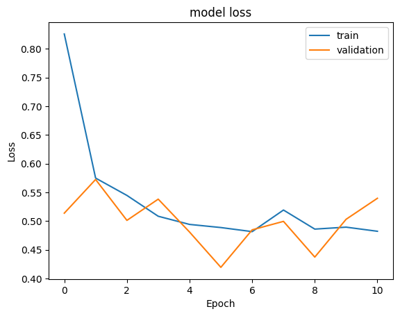

```python
# Plotting Train Loss vs Validation Loss.
plt.plot(history5.history['loss'])
plt.plot(history5.history['val_loss'])
plt.title('model loss')
plt.ylabel('Loss')
plt.xlabel('Epoch')
plt.legend(['train', 'validation'], loc='upper right')
plt.show()
```

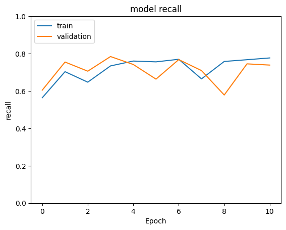

```python
# Plotting Train recall vs Validation recall.
plt.plot(history5.history['recall'])
plt.plot(history5.history['val_recall'])
plt.title('model recall')
plt.ylabel('recall')
plt.xlabel('Epoch')
plt.legend(['train', 'validation'], loc='upper left')
plt.ylim(0, 1)
plt.show()
```

```
Best Threshold=0.470095, G-Mean=0.786
```

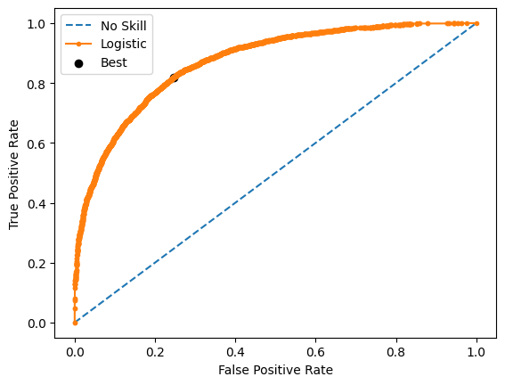

```python
# Predicting probabilities.
yhat5 = model5.predict(X_train_sm)
# Keeping probabilities for the positive outcome only.
yhat5 = yhat5[:, 0]
# Calculating roc curves.
fpr, tpr, thresholds5 = roc_curve(y_train_sm, yhat5)
# Calculating the g-mean for each threshold.
gmeans5 = np.sqrt(tpr * (1-fpr))
# Locating the index of the largest g-mean.
ix = np.argmax(gmeans5)
print('Best Threshold=%f, G-Mean=%.3f' % (thresholds5[ix], gmeans5[ix]))
# Plotting the roc curve for the model.
plt.plot([0,1], [0,1], linestyle='--', label='No Skill')
plt.plot(fpr, tpr, marker='.', label='Logistic')
plt.scatter(fpr[ix], tpr[ix], marker='o', color='black', label='Best')
# Axis labels.
plt.xlabel('False Positive Rate')
plt.ylabel('True Positive Rate')
plt.legend()
# Showing the plot.
plt.show()
```

```python
# Predicting the results using best as a threshold.
y_train_pred5 = model5.predict(X_train_sm)
y_train_pred5 = (y_train_pred5 > thresholds5[ix])
y_train_pred5
```

```
array([[False],
       [False],
       [False],
       ...,
       [ True],
       [ True],
       [ True]])
```

```python
# Predicting the results using best as a threshold.
y_val_pred5 = model5.predict(X_val)
y_val_pred5 = (y_val_pred5 > thresholds5[ix])
y_val_pred5
```

```
array([[ True],
       [False],
       [ True],
       ...,
       [False],
       [False],
       [ True]])
```

```python
model_name = "NN with Balanced Data (by applying SMOTE) and Adam Optimizer"

train_metric_df.loc[model_name] = recall_score(y_train_sm,y_train_pred5)
valid_metric_df.loc[model_name] = recall_score(y_val,y_val_pred5)
```

```python
#classification report
cr=classification_report(y_train_sm,y_train_pred5)
print(cr)
```

```
              precision    recall  f1-score   support

         0.0       0.81      0.75      0.78      5574
         1.0       0.77      0.82      0.79      5574

    accuracy                           0.79     11148
   macro avg       0.79      0.79      0.79     11148
weighted avg       0.79      0.79      0.79     11148
```

```python
#classification report
cr=classification_report(y_val,y_val_pred5)
print(cr)
```

```
              precision    recall  f1-score   support

         0.0       0.93      0.75      0.83      1194
         1.0       0.44      0.77      0.56       306

    accuracy                           0.75      1500
   macro avg       0.68      0.76      0.69      1500
weighted avg       0.83      0.75      0.77      1500
```

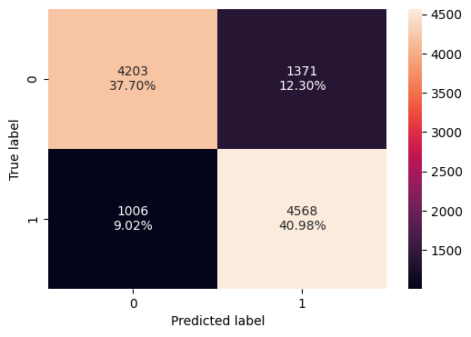

```python
#Calculating the confusion matrix
make_confusion_matrix(y_train_sm, y_train_pred5)
```

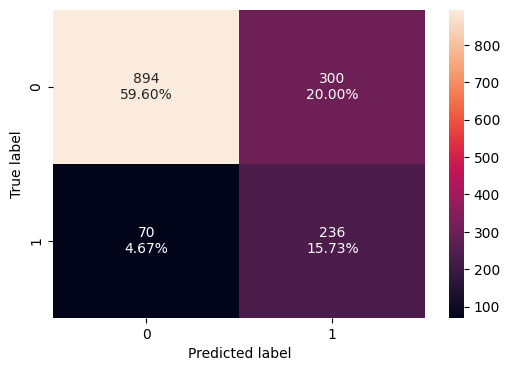

```python
#Calculating the confusion matrix
make_confusion_matrix(y_val, y_val_pred5)
```

**Observations :**

**Neural Network with Balanced Data (by applying SMOTE) and Adam Optimizer**

**Recall Analysis:**

**Training Data:** Non-Churners (Class 0): The model correctly identifies 75% of non-churning customers. Churners (Class 1): The model successfully identifies 82% of the churners, showing slightly better performance for churners.

**Validation Data:** Non-Churners (Class 0): Recall drops to 75%, aligning with the training data. This consistency is positive. Churners (Class 1): Recall is 77%, slightly lower than in training but still strong. This suggests the model effectively captures churners in unseen data.

**Conclusions and Recommendations:**

1.Focus on Improving Precision for Churners

2.Regularization and Hyperparameter Tuning- to reduce overfitting and improving generalization.

3.Evaluate Business Impact:

Given the business context of predicting churn, prioritize reducing false negatives (missing actual churners) even if it means accepting more false positives. This will help in retaining customers more effectively.

- Recall is 0.77 with accuracy of 75%, improved performance with previous model, Results in approx 5 % of customers leaving without the bank attempting to intervene.

### Model Improvement: Neural Network with Balanced Data (by applying SMOTE),Adam Optimizer and Dropout

```python
# Applying SMOTE on training data to oversample data.
sm = SMOTE(sampling_strategy='not majority')
X_train_sm , y_train_sm = sm.fit_resample(X_train,y_train)
print('After resampling, the shape of X_train: {}'.format(X_train_sm.shape))
print('After resampling, the shape of y_train: {} \n'.format(y_train_sm.shape))
```

```
After resampling, the shape of X_train: (11148, 11)
After resampling, the shape of y_train: (11148,)
```

```python
# Checking value counts of y_train before oversampling.
unique_values, counts = np.unique(y_train, return_counts=True)
value_counts = dict(zip(unique_values, counts))
value_counts
```

```
{0.0: 5574, 1.0: 1426}
```

```python
# Checking value counts of y_train_sm after oversampling.
unique_values, counts = np.unique(y_train_sm, return_counts=True)
value_counts = dict(zip(unique_values, counts))
value_counts
```

```
{0.0: 5574, 1.0: 5574}
```

```python
# Clearing backend to help avoid clutter from old models and layers, and clear up memory.
backend.clear_session()
# Fixing the seed for random number generators so that we can ensure we receive the same output everytime.
np.random.seed(13)
import random
random.seed(13)
tf.random.set_seed(13)
```

```python
# Creating a sequential model.
model6 = Sequential()
# Adding the input layer with 32 neurons and relu as the activation function.
model6.add(Dense(32,activation='relu',input_dim = X_train_sm.shape[1]))
# Adding the dropout.
model6.add(Dropout(0.2))
# Adding hidden layer with 16 neurons.
model6.add(Dense(16,activation='relu'))
# Adding the dropout.
model6.add(Dropout(0.1))
# Adding hidden layer with 8 neurons.
model6.add(Dense(8, activation='relu'))
# Adding the output layer.
model6.add(Dense(1, activation = 'relu'))
```

```python
# Printing model summary.
model6.summary()
```

```
Model: "sequential"
_________________________________________________________________
 Layer (type)                Output Shape              Param #
=================================================================
 dense (Dense)               (None, 32)                384

 dropout (Dropout)           (None, 32)                0

 dense_1 (Dense)             (None, 16)                528

 dropout_1 (Dropout)         (None, 16)                0

 dense_2 (Dense)             (None, 8)                 136

 dense_3 (Dense)             (None, 1)                 9

=================================================================
Total params: 1,057
Trainable params: 1,057
Non-trainable params: 0
_________________________________________________________________
```

```python
# Defining EarlyStopping as the callback for this model.
es_cb = keras.callbacks.EarlyStopping(monitor='val_loss', min_delta=0.001, patience=5)

# Initializing Adam optimizer.
optimizer6 = tf.keras.optimizers.Adam(0.001)

# Compiling the model with binary cross entropy as loss and accuracy as metrics.
model6.compile(optimizer=optimizer6,loss = 'binary_crossentropy', metrics = [keras.metrics.Recall()])

# Fitting the model to training data and storing the results.
history6 = model6.fit(X_train_sm,
                      y_train_sm,
                      batch_size=64,
                      epochs=50,
                      verbose=1,
                      validation_data = (X_val,y_val),
                      callbacks=[es_cb])
```

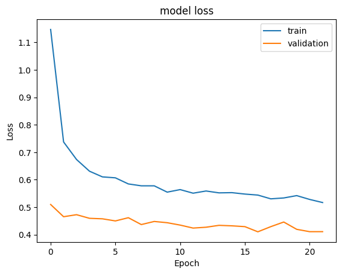

```python
# Plotting Train Loss vs Validation Loss.
plt.plot(history6.history['loss'])
plt.plot(history6.history['val_loss'])
plt.title('model loss')
plt.ylabel('Loss')
plt.xlabel('Epoch')
plt.legend(['train', 'validation'], loc='upper right')
plt.show()
```

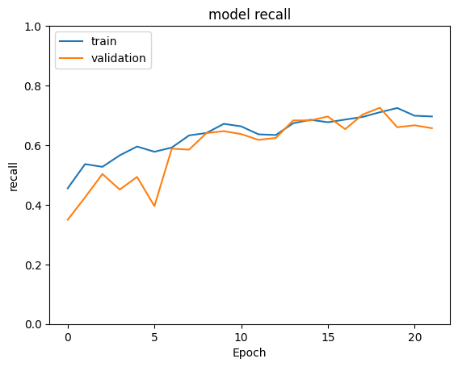

```python
# Plotting Train recall vs Validation recall.
plt.plot(history6.history['recall'])
plt.plot(history6.history['val_recall'])
plt.title('model recall')
plt.ylabel('recall')
plt.xlabel('Epoch')
plt.legend(['train', 'validation'], loc='upper left')
plt.ylim(0, 1)
plt.show()
```

```
Best Threshold=0.426575, G-Mean=0.783
```

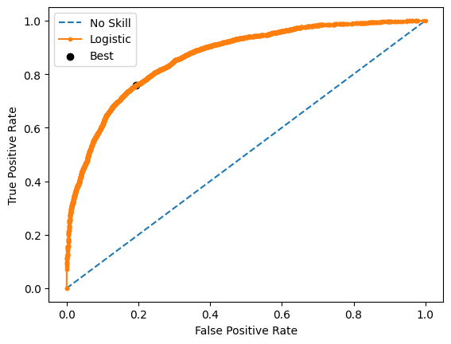

```python
# Predicting probabilities.
yhat6 = model6.predict(X_train_sm)
# Keeping probabilities for the positive outcome only.
yhat6 = yhat6[:, 0]
# Calculating roc curves.
fpr, tpr, thresholds6 = roc_curve(y_train_sm, yhat6)
# Calculating the g-mean for each threshold.
gmeans6 = np.sqrt(tpr * (1-fpr))
# Locating the index of the largest g-mean.
ix = np.argmax(gmeans6)
print('Best Threshold=%f, G-Mean=%.3f' % (thresholds6[ix], gmeans6[ix]))
# Plotting the roc curve for the model.
plt.plot([0,1], [0,1], linestyle='--', label='No Skill')
plt.plot(fpr, tpr, marker='.', label='Logistic')
plt.scatter(fpr[ix], tpr[ix], marker='o', color='black', label='Best')
# Axis labels.
plt.xlabel('False Positive Rate')
plt.ylabel('True Positive Rate')
plt.legend()
# Showing the plot.
plt.show()
```

```python
# Predicting the results using best as a threshold.
y_train_pred6 = model6.predict(X_train_sm)
y_train_pred6 = (y_train_pred6 > thresholds5[ix])
y_train_pred6
```

```
array([[False],
       [False],
       [False],
       ...,
       [ True],
       [ True],
       [False]])
```

```python
# Predicting the results using best as a threshold.
y_val_pred6 = model6.predict(X_val)
y_val_pred6 = (y_val_pred6 > thresholds5[ix])
y_val_pred6
```

```
array([[False],
       [False],
       [ True],
       ...,
       [False],
       [False],
       [ True]])
```

```python
model_name = "NN with Balanced Data (by applying SMOTE). Adam Optimizer and Dropout"

train_metric_df.loc[model_name] = recall_score(y_train_sm,y_train_pred6)
valid_metric_df.loc[model_name] = recall_score(y_val,y_val_pred6)
```

```python
#classification report
cr=classification_report(y_train_sm,y_train_pred6)
print(cr)
```

```
              precision    recall  f1-score   support

         0.0       0.71      0.89      0.79      5574
         1.0       0.85      0.64      0.73      5574

    accuracy                           0.77     11148
   macro avg       0.78      0.77      0.76     11148
weighted avg       0.78      0.77      0.76     11148
```

```python
#classification report
cr=classification_report(y_val,y_val_pred6)
print(cr)
```

```
              precision    recall  f1-score   support

         0.0       0.90      0.89      0.90      1194
         1.0       0.60      0.63      0.61       306

    accuracy                           0.84      1500
   macro avg       0.75      0.76      0.75      1500
weighted avg       0.84      0.84      0.84      1500
```

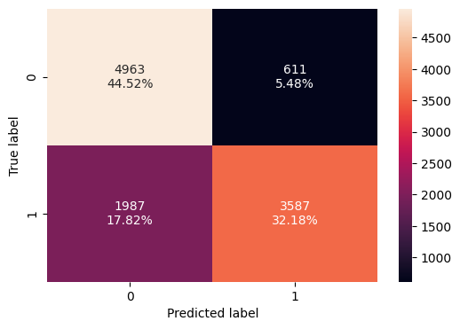

```python
#Calculating the confusion matrix
make_confusion_matrix(y_train_sm, y_train_pred6)
```

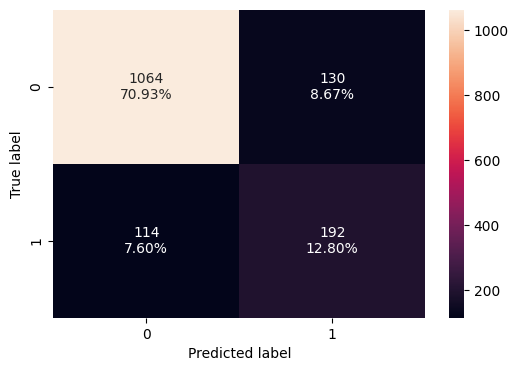

```python
#Calculating the confusion matrix
make_confusion_matrix(y_val, y_val_pred6)
```

**Observations :** **Neural Network with Balanced Data (by applying SMOTE),Adam Optimizer and Dropout**

**Recall Analysis:**

**Training Data:** Non-Churners (Class 0): The model has a high recall of 89%, meaning it correctly identifies 89% of the non-churning customers. This indicates the model is highly effective in capturing non-churners. Churners (Class 1): The recall for churners is 64%, indicating the model correctly identifies 64% of the customers who churn. This suggests a moderate ability to detect churners during training.

**Validation Data:** Non-Churners (Class 0): Recall remains high at 89%, showing consistent performance in identifying non-churners on unseen data. Churners (Class 1): Recall is 63%, slightly lower than in training but still within a reasonable range. This indicates the model’s capacity to generalize for churners is stable but could be improved.

**Accuracy and Averages:**

1.Training Data: The model achieves an accuracy of 0.77, meaning it correctly predicts 77% of the instances. The macro and weighted averages show balanced performance across both classes.

2.Validation Data: Accuracy improves to 0.84, indicating that 84% of predictions are correct. The weighted average F1-Score of 0.84 suggests the model is robust in general, but with room for improvement in churn predictions.

**Conclusions and Recommendations:**

1.Focus on Balanced Performance : The goal is to achieve a better balance between precision and recall for churners, ensuring that the model not only captures true churners effectively but also minimizes the number of false alarms (non-churners predicted as churners).

2.Evaluate Business Impact: From a business perspective, the priority should be reducing false negatives (missed churners), even at the cost of accepting more false positives. This approach will help retain customers more effectively, aligning with business goals.

3.Consider Advanced Architectures: Exploring deeper neural network architectures or incorporating techniques like dropout and batch normalization could enhance the model's ability to capture complex patterns and improve performance for the minority class (churners).

4.Regularization and Hyperparameter Tuning: Applying regularization techniques and tuning hyperparameters helps in reducing overfitting, leading to better generalization and improved recall and precision metrics for churners.

## Model Performance Comparison and Final Model Selection

```python
print("Training performance comparison")
train_metric_df
```

```
Training performance comparison
```

|  | recall |
| --- | --- |
| NN with SGD | 0.432 |
| NN with Adam Optimizer | 0.854 |
| NN with Adam Optimizer and Dropout | 0.875 |
| NN with Balanced Data (by applying SMOTE) and SGD Optimizer | 0.681 |
| NN with Balanced Data (by applying SMOTE) and Adam Optimizer | 0.820 |
| NN with Balanced Data (by applying SMOTE). Adam Optimizer and Dropout | 0.644 |

```python
print("Validation set performance comparison")
valid_metric_df
```

```
Validation set performance comparison
```

|  | recall |
| --- | --- |
| NN with SGD | 0.422 |
| NN with Adam Optimizer | 0.755 |
| NN with Adam Optimizer and Dropout | 0.761 |
| NN with Balanced Data (by applying SMOTE) and SGD Optimizer | 0.706 |
| NN with Balanced Data (by applying SMOTE) and Adam Optimizer | 0.771 |
| NN with Balanced Data (by applying SMOTE). Adam Optimizer and Dropout | 0.627 |

```python
train_metric_df - valid_metric_df
```

|  | recall |
| --- | --- |
| NN with SGD | 0.010 |
| NN with Adam Optimizer | 0.099 |
| NN with Adam Optimizer and Dropout | 0.114 |
| NN with Balanced Data (by applying SMOTE) and SGD Optimizer | -0.025 |
| NN with Balanced Data (by applying SMOTE) and Adam Optimizer | 0.048 |
| NN with Balanced Data (by applying SMOTE). Adam Optimizer and Dropout | 0.016 |

**Observations :**

**NN with Balanced Data (by applying SMOTE) and Adam Optimizer shows higest recall (0.771) on validation set, amongst all other models so selecting as final model to be compared with test set.**

**NN with Balanced Data (SMOTE) and Adam Optimizer Performance:**

**Training Recall**: 0.820

**Validation Recall**: 0.771 This model performance is well on the validation set, suggesting good generalization and the ability to handle new data effectively, indicating it is the most effective at identifying customers who are likely to churn.

**Why Model is Effective**

## Final Model

**Observations :**

NN with Balanced Data (by applying SMOTE) and Adam Optimizer shows higest recall (0.771) on validation set, amongst all other models so selecting as final model to be compared with test set.

```python
# Creating variable model_final to be used as the final model.
model_final = model5
```

```
Best Threshold=0.458816, G-Mean=0.771
```

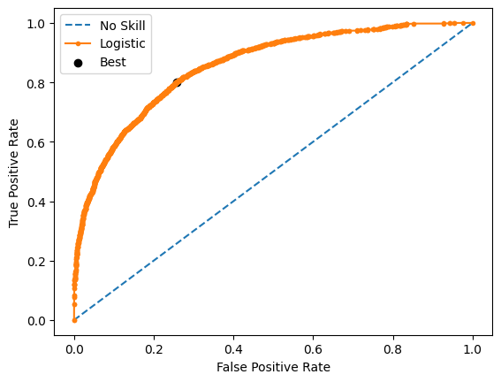

```python
# Predicting probabilities using the final model.
yhat_f = model_final.predict(X_train)
# Keeping probabilities for the positive outcome only.
yhat_f = yhat_f[:, 0]
# Calculating roc curves.
fpr, tpr, thresholds_f = roc_curve(y_train, yhat_f)
# Calculating the g-mean for each threshold.
gmeans_f = np.sqrt(tpr * (1-fpr))
# Locating the index of the largest g-mean.
ix = np.argmax(gmeans_f)
print('Best Threshold=%f, G-Mean=%.3f' % (thresholds_f[ix], gmeans_f[ix]))
# Plotting the roc curve for the final model.
plt.plot([0,1], [0,1], linestyle='--', label='No Skill')
plt.plot(fpr, tpr, marker='.', label='Logistic')
plt.scatter(fpr[ix], tpr[ix], marker='o', color='black', label='Best')
# Axis labels.
plt.xlabel('False Positive Rate')
plt.ylabel('True Positive Rate')
plt.legend()
# Showing the plot.
plt.show()
```

```python
# Predicting the results on test data using best as a threshold.
y_test_pred_final = model_final.predict(X_test)
y_test_pred_final = (y_test_pred_final > thresholds_f[ix])
print(y_test_pred_final)
```

```
[[ True]
 [False]
 [False]
 ...
 [False]
 [False]
 [ True]]
```

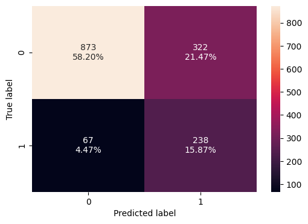

```python
#Calculating the confusion matrix
make_confusion_matrix(y_test, y_test_pred_final)
```

```python
# Accuracy as per the classification report.
cr_final = sklearn.metrics.classification_report(y_test, y_test_pred_final)
print(cr_final)
```

```
              precision    recall  f1-score   support

         0.0       0.93      0.73      0.82      1195
         1.0       0.42      0.78      0.55       305

    accuracy                           0.74      1500
   macro avg       0.68      0.76      0.68      1500
weighted avg       0.83      0.74      0.76      1500
```

**Observations :**

**Model5(NN with Balanced Data (SMOTE) and Adam Optimizer) shows good performance i.e 78% Recall score with 74% accuracy , hence recommended for bank to use as predective model to retain customers and reduce churn rate.**

- Accuracy: The overall accuracy (0.74) indicates the model is classifying correctly most of the time (74%).
- Precision (Class 0): The model is very precise (0.93) in identifying negative examples (class 0). This means when it predicts something as negative, it's usually correct.
- Recall (Class 1): The model struggles with recall (0.78) for positive examples (class 1). This means it misses a significant portion (22%) of actual positives.
- Precision (Class 1): The precision (0.42) for positive examples is also low. This indicates that out of the examples it predicts as positive, only 42% are truly positive. There are many false positives.

**Actionable Insights:**

**Focus on Class 1:** Given the importance of correctly classifying positive examples (class 1), prioritize improving recall and precision for this class. Techniques like oversampling or undersampling the training data can help address class imbalance, on further model performance, as & when needed.

**Cost-Sensitive Learning:** If misclassifying positive examples is more critical than misclassifying negatives, considering cost-sensitive learning we can assign a higher cost to misclassifying class 1 during training.

**Hyperparameter Tuning:** Experiment with different hyperparameters of neural network architecture (e.g., number of layers, learning rate) to see if it improves performance on class 1.

**Alternative Metrics:** Depending on the specific problem, using metrics like F1-score that considers both precision and recall might be more informative than just accuracy.

## Actionable Insights and Recommendations

**What recommedations would you suggest to the bank?**

**Observations**

**Actionable Insights & Recommendations**

- Bank can Offer some incentive to customers who shows interest to retain their business with bank.
- Its recommended to bank to Create dashboards and alerts for customer service teams to intervene with at-risk customers.
- Design targeted retention campaigns based on predicted churn risk and customer segment.
- Enhance Customer Service and Support, eg, provide proactive supporrt by Reaching out to customers who are showing signs of disengagement with personalized offers or support.
- Identify early signs of dissatisfaction (e.g., reduced activity, increased complaints) & provide tailored service experiences based on customer profiles and preferences.